# Facebook Messenger Analytics

*Note: Due to the deeply personal nature of this data, I've kept the raw data off of Github and obscured any personally identifiable information.*

Contents:

- Load Data
- Initial Exploration
- Feature Engineering
  - Basic Features
  - Sentiment Scoring
  - Profanity Identification
- Data Visualizations
  - Content Types
  - Trends over Time
  - Example Friend Analysis
- Aggregated Analyses
  - By Sender

## Loading Data & Initial Exploration

Loading data obtained through Facebook's "Download your Information" feature. Each thread (group chats and direct messages) was combined into a single CSV file used here. For additional information on how to pull your own data, click [here](https://www.facebook.com/help/1701730696756992).

```python
import pandas as pd
```

```python
data = pd.read_csv('Cleaned_messages.csv')
```

```python
data.drop(['sender_name', 'content', 'participants', 'users'], axis = 1).head() # Hiding sender name, thread name, and message contents
```

|  | Unnamed: 0 | timestamp_ms | type | sticker | title | is_still_participant | thread_type | thread_path | photos | share | reactions | files | ip | call_duration | missed | gifs | audio_files | videos |
| --- | --- | --- | --- | --- | --- | --- | --- | --- | --- | --- | --- | --- | --- | --- | --- | --- | --- | --- |
| 0 | 0 | 1485302620404 | Unsubscribe | NaN | 36303 group | False | RegularGroup | archived_threads/36303group_pgmwn-_5fa | NaN | NaN | NaN | NaN | NaN | NaN | NaN | NaN | NaN | NaN |
| 1 | 1 | 1485297599245 | Generic | NaN | 36303 group | False | RegularGroup | archived_threads/36303group_pgmwn-_5fa | NaN | NaN | NaN | NaN | NaN | NaN | NaN | NaN | NaN | NaN |
| 2 | 2 | 1485292477100 | Generic | {'uri': 'messages/stickers_used/39178562_15051... | 36303 group | False | RegularGroup | archived_threads/36303group_pgmwn-_5fa | NaN | NaN | NaN | NaN | NaN | NaN | NaN | NaN | NaN | NaN |
| 3 | 3 | 1485292467803 | Generic | NaN | 36303 group | False | RegularGroup | archived_threads/36303group_pgmwn-_5fa | NaN | NaN | NaN | NaN | NaN | NaN | NaN | NaN | NaN | NaN |
| 4 | 4 | 1485292439211 | Generic | {'uri': 'messages/stickers_used/851587_3692393... | 36303 group | False | RegularGroup | archived_threads/36303group_pgmwn-_5fa | NaN | NaN | NaN | NaN | NaN | NaN | NaN | NaN | NaN | NaN |

```python
data.shape # Number of rows and columns
```

```
(613195, 22)
```

Each message is attached to a sender ("sender_name" column) and a thread ("participants" column). In 1-on-1 chats, the thread is just the name of myself and the person I am messaging. In groupchats, the thread is a list of all participants in the chat. For example, if I was just DM'ing Scooby Doo, the sender might be "Scooby Doo", and the thread might be "Scooby Doo, Aliya Zee". However, if I was in a group chat with the whole gang, the sender could be anyone from the gang (depending on who sent the message) and the thread would be "Aliya Zee, Scooby Doo, Shaggy, Daphne, Velma, Fred".

I obscure these for privacy reasons below.

```python
# Obscuring sender_name from the name of the sender to their rank in total messages
# I am Sender_0, and my top friends are therefore Sender_1, Sender_2, etc.
name_key = pd.DataFrame(data.value_counts('sender_name')).reset_index().reset_index()
name_key.columns = ['sender_name_code', 'sender_name', 'sender_count']
name_key['sender_name_code'] = "Sender_" + name_key['sender_name_code'].astype('str')
data = pd.merge(data, name_key, on = 'sender_name', how = 'left')

# Obscuring participants from the name of the participants list to their rank in total messages
# My longest thread is Thread_0, second-longest is Thread_1, etc.
thread_key = pd.DataFrame(data.value_counts('participants')).reset_index().reset_index()
thread_key.columns = ['participants_code', 'participants', 'participants_count']
thread_key['participants_code'] = "Thread_" + thread_key['participants_code'].astype('str')
data = pd.merge(data, thread_key, on = 'participants', how = 'left')
```

```python
# Setting up easy filters for later analysis
top5_friends = data.value_counts('sender_name').index.values[1:6] # Excludes myself
top20_friends = data.value_counts('sender_name').index.values[1:21] # Excludes myself
top10_senders = data.value_counts('sender_name').index.values[0:10] # Includes myself

# Creating a clearer column for filtering messages I send vs the ones I receive
data['Direction'] = "Received"
data.loc[data['sender_name_code'] == "Sender_0", 'Direction'] = "Sent"
```

## Feature Engineering

Creating additional features to enable deeper analysis.

### Basic Features

```python
# Creating aggregated date columns
data['Datetime'] = pd.to_datetime(data['timestamp_ms'], unit = 'ms')
data['Date'] = data['Datetime'].dt.date
data['Year-Month'] = data['Datetime'].values.astype('datetime64[M]')

import numpy as np
# Creating a column counting the number of characters used
data['Text_length'] = data['content'].str.len()
# Messages with a call/subscribe type contain standardized sentences in the "content" column. These get cleared to NA values
data.loc[data['type'].isin(['Call', 'Subscribe', 'Unsubscribe']), 'Text_length'] = np.NaN

# Adding simple T/F columns for emoji. Future analysis could include proper emoji as well.
data['emoji_happy'] = data['content'].str.contains(':)', regex = False, na = False)
data['emoji_sad'] = data['content'].str.contains(':(', regex = False, na = False)
data['emoji_xD'] = data['content'].str.contains('xD', regex = False, na = False) # We all make mistakes

# Identifying groupchats
data['groupchat'] = (data['thread_type'] == 'RegularGroup')
```

```python
# Dropping a filler column, the original timestamp, unused threadtype and ip (only my ip was included)
data.drop(['Unnamed: 0', 'timestamp_ms', 'ip', 'thread_type'], axis = 1, inplace = True)
```

### Sentiment Scoring

Using VaderSentiment to identify positive, negative, neutral, and compound sentiment scores for each message. To clarify the meaning of these scores, please reference the following definitions found [here](https://github.com/cjhutto/vaderSentiment).

> The pos, neu, and neg scores are ratios for proportions of text that fall in each category (so these should all add up to be 1... or close to it with float operation). These are the most useful metrics if you want multidimensional measures of sentiment for a given sentence.

> The compound score is computed by summing the valence scores of each word in the lexicon, adjusted according to the rules, and then normalized to be between -1 (most extreme negative) and +1 (most extreme positive). This is the most useful metric if you want a single unidimensional measure of sentiment for a given sentence. Calling it a 'normalized, weighted composite score' is accurate.

```python
import nltk
from nltk.corpus import stopwords
stop_words=stopwords.words('english')
```

```python
from vaderSentiment.vaderSentiment import SentimentIntensityAnalyzer
sid = SentimentIntensityAnalyzer()
```

```python
data['content'] = data['content'].fillna('')
data['content_clean'] = data['content'].str.lower().str.replace('[^a-zA-Z ]', '')
data["content_without_stopwords"] = data["content_clean"].apply(lambda x: [i for i in x.split() if i not in stop_words])
```

```python
import datetime
print("Starting at ", datetime.datetime.now())
data["Compound_Score"] = [sid.polarity_scores(x)['compound'] for x in data["content_without_stopwords"]]
data["Negative_Score"] = [sid.polarity_scores(x)['neg'] for x in data["content_without_stopwords"]]
data["Neutral_Score"] = [sid.polarity_scores(x)['neu'] for x in data["content_without_stopwords"]]
data["Positive_Score"] = [sid.polarity_scores(x)['pos'] for x in data["content_without_stopwords"]]
print("Ending at ", datetime.datetime.now())
```

```
Starting at  2021-01-04 14:00:06.768530
Ending at  2021-01-04 14:00:41.634255
```

### Profanity Identification

This section is a work in progress.

```python
from better_profanity import profanity

# print("Starting at ", datetime.datetime.now())
# data['contains_profanity'] = data['content_clean'].apply(profanity.contains_profanity)
# print("Ending at ", datetime.datetime.now())
```

```python
# Export to CSV for other analyses
# data.to_csv('Messenger Post-Processing.csv')
```

## Data Visualizations

Mostly an excuse to practice Seaborn, but also a great way to visualize some interesting insights with the features engineered above.

```python
import seaborn as sns
from matplotlib import pyplot as plt

%matplotlib inline
sns.set_theme()
```

### Content Types

Content types separate standard ("Generic") messages from shares, calls, subscriptions (getting added or removed from a group).

```python
data.value_counts('type')
```

```
type
Generic        608367
Share            3800
Call              460
Subscribe         357
Unsubscribe       211
dtype: int64
```

```
[Text(0.5, 1.0, 'Total Messages'), Text(0, 0.5, 'Messages')]
```

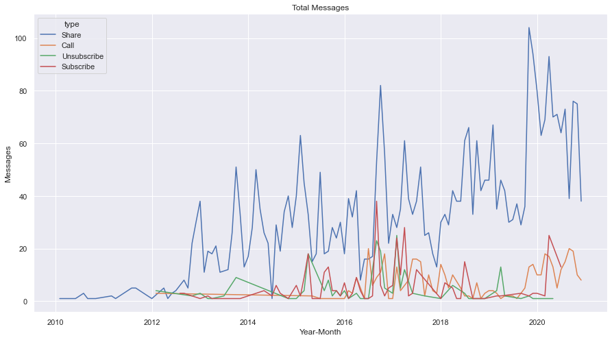

```python
graph_data = data.copy()[data['type'] != 'Generic']

graph_data = graph_data.groupby(['Year-Month', 'type'])['content'].count()
graph_data = graph_data.reset_index()

plt.figure(figsize=(15,8))
g = sns.lineplot(data = graph_data, x = 'Year-Month', y = 'content', hue = 'type')
g.set(title = 'Total Messages', ylabel = 'Messages')
```

```
[Text(0.5, 1.0, 'Total Calls'), Text(0, 0.5, 'Calls')]
```

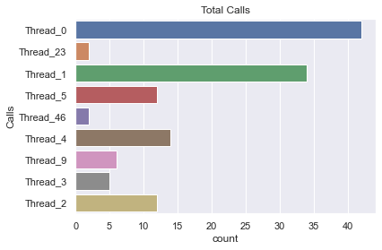

```python
graph_data = data.copy()[data['type'] == 'Call']
graph_data = graph_data[graph_data['sender_name'].isin(top5_friends)]

g = sns.countplot(data = graph_data, y = 'participants_code')
g.set(title = 'Total Calls', ylabel = 'Calls')
```

```
[Text(0.5, 1.0, 'Total Shares'), Text(0, 0.5, 'Calls')]
```

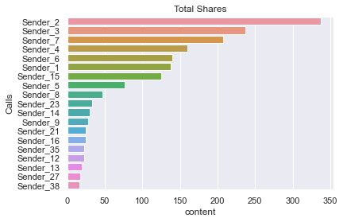

```python
graph_data = data.copy()[data['type'] == 'Share']
graph_data = graph_data.groupby(['sender_name_code'])['content'].count().sort_values(ascending = False).reset_index()[1:20]

g = sns.barplot(data = graph_data, y = 'sender_name_code', x = 'content')
g.set(title = 'Total Shares', ylabel = 'Calls')
```

```
[Text(0.5, 1.0, '% Calls'), Text(0, 0.5, 'Sender')]
```

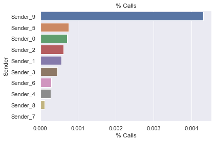

```python
graph_data = data.copy()#[data['type'] == 'Share']
graph_data = graph_data[graph_data['sender_name'].isin(top10_senders)]
graph_data = graph_data.groupby(['sender_name_code', 'type'])['content'].count().reset_index()

graph_data = pd.pivot_table(graph_data, values='content', index=['sender_name_code'],
                            columns=['type'], aggfunc=np.sum).fillna(0)

graph_data['total'] = graph_data.sum(axis = 1)
graph_data['% Calls'] = graph_data['Call'] / graph_data['total']

g = sns.barplot(data = graph_data.sort_values(by = '% Calls', ascending = False).reset_index()[0:10], y = 'sender_name_code', x = '% Calls')
g.set(title = '% Calls', ylabel = 'Sender')
```

### Timeline Trends

```
[Text(0.5, 1.0, 'Total Messages'), Text(0, 0.5, 'Messages')]
```

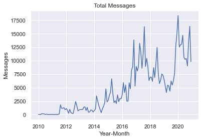

```python
graph_data = data.copy()
graph_data = graph_data.groupby(['Year-Month'])['content'].count()
graph_data = graph_data.reset_index()

g = sns.lineplot(data = graph_data, x = 'Year-Month', y = 'content')
g.set(title = 'Total Messages', ylabel = 'Messages')
```

```
[Text(0.5, 1.0, 'Average Sentiment'), Text(0, 0.5, 'Average Compound Score')]
```

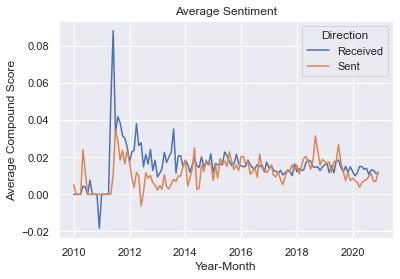

```python
graph_data = data.copy()
graph_data = graph_data.groupby(['Year-Month', 'Direction'])['Compound_Score'].mean()
graph_data = graph_data.reset_index()

g = sns.lineplot(data = graph_data, x = 'Year-Month', y = 'Compound_Score', hue = 'Direction')
g.set(title = 'Average Sentiment', ylabel = 'Average Compound Score')
```

```
[Text(0.5, 1.0, 'Total Messages (by Top 5 Friends)'), Text(0, 0.5, 'Messages')]
```

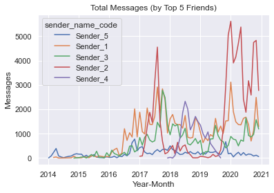

```python
graph_data = data.copy()[data['sender_name'].isin(top5_friends)]

graph_data = graph_data.groupby(['Year-Month', 'sender_name_code'])['content'].count()
graph_data = graph_data.reset_index()

g = sns.lineplot(data = graph_data, x = 'Year-Month', y = 'content', hue = 'sender_name_code')
g.set(title = 'Total Messages (by Top 5 Friends)', ylabel = 'Messages')
```

```
[Text(0.5, 1.0, 'Average Sentiment'), Text(0, 0.5, 'Average Compound Score')]
```

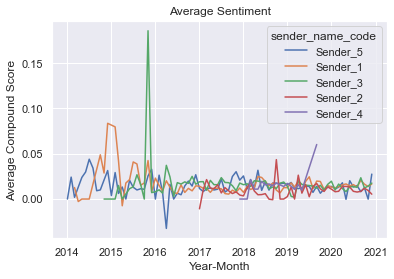

```python
graph_data = data.copy()[data['sender_name'].isin(top5_friends)]
graph_data = graph_data.groupby(['Year-Month', 'sender_name_code'])['Compound_Score'].mean()
graph_data = graph_data.reset_index()

g = sns.lineplot(data = graph_data, x = 'Year-Month', y = 'Compound_Score', hue = 'sender_name_code')
g.set(title = 'Average Sentiment', ylabel = 'Average Compound Score')
```

```
[Text(0.5, 1.0, 'xD Emoji Usage'), Text(0, 0.5, "xD's used")]
```

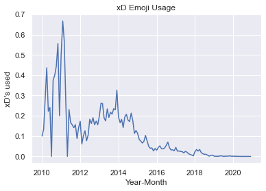

```python
graph_data = data.copy()[data['sender_name'] == 'Aliya Zhdanov']
graph_data = graph_data.groupby(['Year-Month'])['emoji_xD'].mean()
graph_data = graph_data.reset_index()

g = sns.lineplot(data = graph_data, x = 'Year-Month', y = 'emoji_xD')
g.set(title = """xD Emoji Usage""", ylabel = """xD's used""")
```

### Example Friend Analysis

The following charts focus on analyzing the texts between myself and a college friend, in just our 1-on-1 thread (excluding groupchats). Overall findings show that this friend ("Sender_6") sends more texts in our conversations, but uses fewer emoji and tends to be slightly more positive. We also text more often on weekdays.

[output not shown]

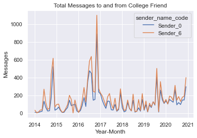

```python
graph_data = data.copy()[data['participants_code'] == "Thread_7"]
graph_data = graph_data.groupby(['Year-Month', 'sender_name_code'])['content'].count()
graph_data = graph_data.reset_index()

g = sns.lineplot(data = graph_data, x = 'Year-Month', y = 'content', hue = 'sender_name_code')
g.set(title = 'Total Messages to and from College Friend', ylabel = 'Messages')
```

```
[Text(0.5, 1.0, 'Average Sentiment'), Text(0, 0.5, 'Average Compound Score')]
```

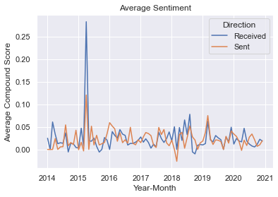

```python
graph_data = data.copy()[data['participants_code'] == "Thread_7"]
graph_data = graph_data.groupby(['Year-Month', 'Direction'])['Compound_Score'].mean()
graph_data = graph_data.reset_index()

g = sns.lineplot(data = graph_data, x = 'Year-Month', y = 'Compound_Score', hue = 'Direction')
g.set(title = 'Average Sentiment', ylabel = 'Average Compound Score')
```

```
[Text(0.5, 1.0, 'Total Messages'), Text(0, 0.5, 'Sender')]
```

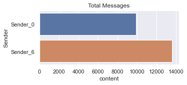

```python
graph_data = data.copy()[data['participants_code'] == "Thread_7"]
graph_data = graph_data.groupby(['sender_name_code'])['content'].count()
graph_data = graph_data.reset_index()

plt.figure(figsize=(5, 2))
g = sns.barplot(data = graph_data, y = 'sender_name_code', x = 'content')
g.set(title = 'Total Messages', ylabel = 'Sender')
```

```
[Text(0.5, 1.0, 'Total Text Length'), Text(0, 0.5, 'Sender')]
```

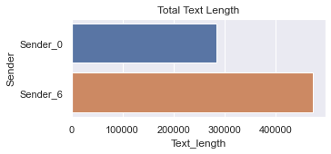

```python
graph_data = data.copy()[data['participants_code'] == "Thread_7"]
graph_data = graph_data.groupby(['sender_name_code'])['Text_length'].sum()
graph_data = graph_data.reset_index()

plt.figure(figsize=(5, 2))
g = sns.barplot(data = graph_data, y = 'sender_name_code', x = 'Text_length')
g.set(title = 'Total Text Length', ylabel = 'Sender')
```

```
[Text(0.5, 1.0, 'Average Text Length'), Text(0, 0.5, 'Sender')]
```

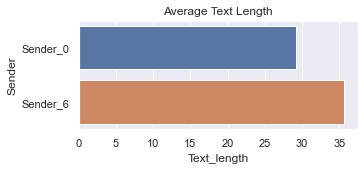

```python
graph_data = data.copy()[data['participants_code'] == "Thread_7"]
graph_data = graph_data.groupby(['sender_name_code'])['Text_length'].mean()
graph_data = graph_data.reset_index()

plt.figure(figsize=(5, 2))
g = sns.barplot(data = graph_data, y = 'sender_name_code', x = 'Text_length')
g.set(title = 'Average Text Length', ylabel = 'Sender')
```

```
[Text(0.5, 1.0, 'Total Happy emoji'), Text(0, 0.5, 'Sender')]
```

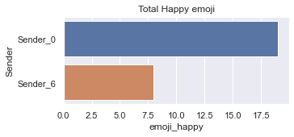

```python
graph_data = data.copy()[data['participants_code'] == "Thread_7"]
graph_data = graph_data.groupby(['sender_name_code'])['emoji_happy'].sum()
graph_data = graph_data.reset_index()

plt.figure(figsize=(5, 2))
g = sns.barplot(data = graph_data, y = 'sender_name_code', x = 'emoji_happy')
g.set(title = 'Total Happy emoji', ylabel = 'Sender')
```

```
[Text(0.5, 1.0, 'Total Sad emoji'), Text(0, 0.5, 'Sender')]
```

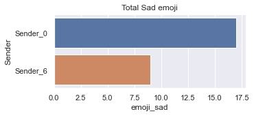

```python
graph_data = data.copy()[data['participants_code'] == "Thread_7"]
graph_data = graph_data.groupby(['sender_name_code'])['emoji_sad'].sum()
graph_data = graph_data.reset_index()

plt.figure(figsize=(5, 2))
g = sns.barplot(data = graph_data, y = 'sender_name_code', x = 'emoji_sad')
g.set(title = 'Total Sad emoji', ylabel = 'Sender')
```

[output not shown]

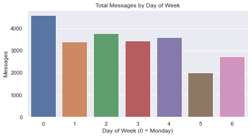

```python
graph_data = data.copy()[data['participants_code'] == "Thread_7"]
graph_data['Day_of_Week'] = graph_data['Datetime'].dt.dayofweek
graph_data = graph_data.groupby(['Day_of_Week'])['content'].count()
graph_data = graph_data.reset_index()

plt.figure(figsize=(8, 4))
g = sns.barplot(data = graph_data, y = 'content', x = 'Day_of_Week')
g.set(title = 'Total Messages by Day of Week', ylabel = 'Messages', xlabel = 'Day of Week (0 = Monday)')
```

```python
# graph_data = data.copy()[data['participants_code'] == "Thread_7"]
# graph_data = graph_data.groupby(['sender_name_code'])['contains_profanity'].sum()
# graph_data = graph_data.reset_index()

# plt.figure(figsize=(5, 2))
# g = sns.barplot(data = graph_data, y = 'sender_name_code', x = 'contains_profanity')
# g.set(title = 'Total Profanity Used', ylabel = 'Sender')
```

## Aggregate Analyses

### Sender Master Table

So far, most of the data has been at the day/month grain. Instead, it may be helpful to aggregate the data at the sender level to identify characteristics and see if there are any non-obvious underlying correlations.

This is a work in progress.

```python
senders = data.groupby('sender_name').agg({'content': 'count',
                                'Text_length': 'sum',
                                'Compound_Score': 'mean',
                                'sticker': 'count',
                                'participants': 'nunique',
                                'photos': 'count',
                                'share': 'count',
                                'reactions': 'count',
                                'files': 'count',
                                'call_duration': 'count',
                                'missed': 'count',
                                'gifs': 'count',
                                'audio_files': 'count',
                                'videos': 'count',
                                'Date': 'nunique'})
```

```python
senders_sub =  senders.loc[top20_friends]
```

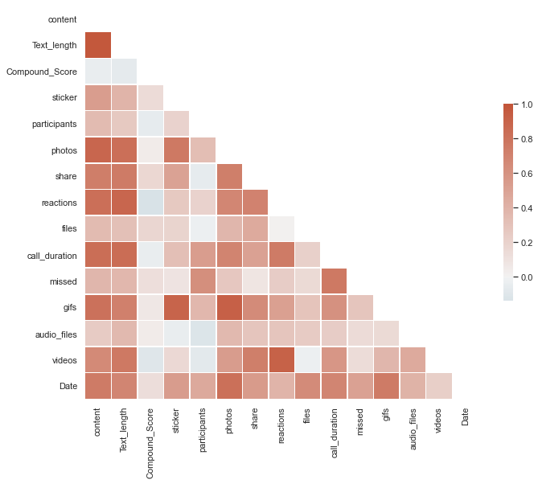

```python
from string import ascii_letters
import numpy as np
import pandas as pd
import seaborn as sns
import matplotlib.pyplot as plt

sns.set_theme(style="white")

# # Generate a large random dataset
# rs = np.random.RandomState(33)
# d = pd.DataFrame(data=rs.normal(size=(100, 26)),
#                  columns=list(ascii_letters[26:]))

# Compute the correlation matrix
corr = senders_sub.corr()

# Generate a mask for the upper triangle
mask = np.triu(np.ones_like(corr, dtype=bool))

# Set up the matplotlib figure
f, ax = plt.subplots(figsize=(11, 9))

# Generate a custom diverging colormap
cmap = sns.diverging_palette(230, 20, as_cmap=True)

# Draw the heatmap with the mask and correct aspect ratio
sns.heatmap(corr, mask=mask, cmap=cmap, vmax=1, center=0,
            square=True, linewidths=.5, cbar_kws={"shrink": .5})
```

```python
data.sender_name.nunique()
```

```
843
```